# Version 2: Bay Area Used Vehicle Price Prediction

Alex Alvarez

2026-06-05

```r
knitr::opts_chunk$set(
  echo = FALSE,
  warning = FALSE,
  message = FALSE
)
```

# Analysis

## 16,000

Raw Listings

## 14,320

Modeling Observations

## V2

Enhanced Price Model

This report extends Version 1 of the Bay Area used vehicle market project by adding feature engineering, vehicle make extraction, regression modeling, Random Forest modeling, and a price prediction framework.

The goal is to estimate used vehicle market value using vehicle mileage, model year, and manufacturer information.

## Data Preparation

The dataset was created from scraped Craigslist vehicle listings. This section reloads the raw CSV, cleans price, mileage, and year variables, removes incomplete observations, and filters extreme outliers.

| Metric | Count |
| --- | --- |
| Raw Listings | 16000 |
| Cleaned Listings | 15280 |
| Final Modeling Observations | 14320 |

## Feature Engineering

Feature engineering is the process of creating new variables from existing information. In this project, vehicle manufacturer information is extracted from listing titles and used as an additional predictor of market value.

| make | n |
| --- | --- |
| Toyota | 2000 |
| Honda | 1280 |
| BMW | 960 |
| Mercedes-Benz | 960 |
| Ford | 880 |
| Dodge | 640 |
| Nissan | 560 |
| Chevrolet | 480 |
| Subaru | 480 |
| Jeep | 400 |

[output cut: 10 more lines]

Toyota was the most frequently listed vehicle manufacturer in the dataset with 2,000 observations, followed by Honda with 1,280 listings. Luxury brands such as BMW and Mercedes-Benz were also strongly represented. These results suggest that both mainstream and premium vehicle segments are active within the Bay Area used vehicle market.

## Exploratory Data Analysis

Summary statistics provide a high-level overview of vehicle prices, mileage, and model years within the Bay Area used vehicle market.

| Statistic | Value |
| --- | --- |
| Average Price | 17223 |
| Average Mileage | 100180 |
| Average Year | 2014 |
| Median Price | 13000 |
| Median Mileage | 94000 |

The average vehicle price in the dataset is approximately $17,223, while the median vehicle price is $13,000. The average mileage is approximately 100,180 miles, with a median mileage of 94,000 miles. The average model year is 2014, indicating that most vehicles in the dataset are approximately 10 to 12 years old.

## Price vs Mileage

Vehicle mileage is expected to have a negative relationship with vehicle value. As vehicles accumulate mileage, depreciation generally reduces market price.

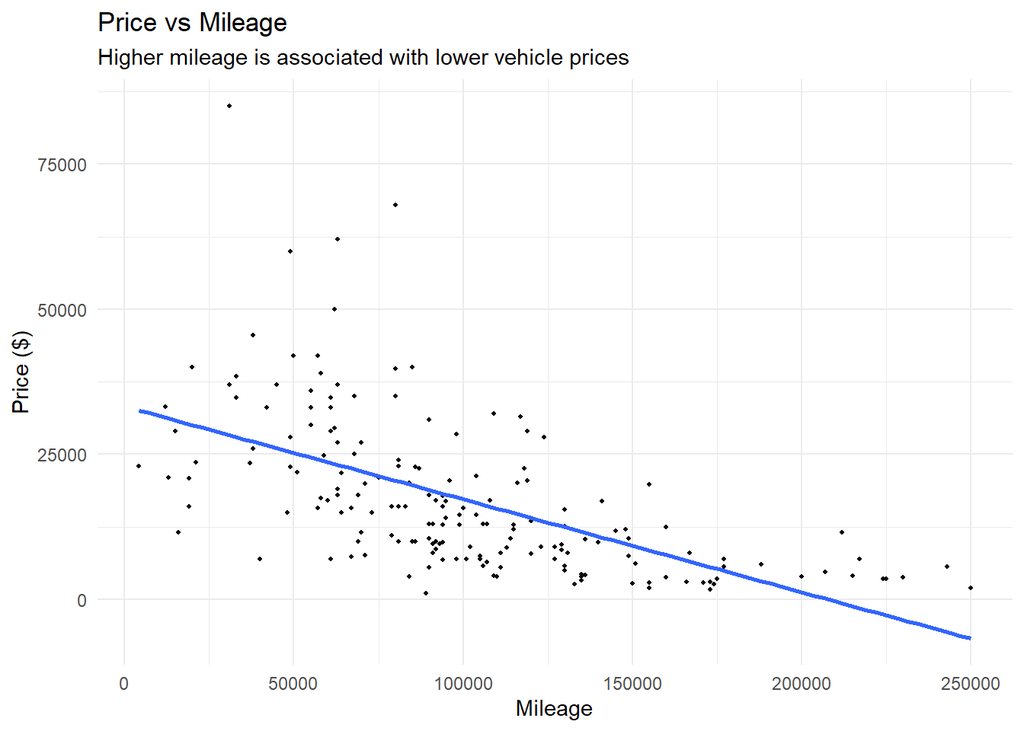

The scatterplot shows a negative relationship between mileage and price. Vehicles with higher mileage generally have lower market values, which is consistent with depreciation. This visual relationship supports including mileage as an explanatory variable in the regression model.

## Price vs Model Year

Vehicle model year is expected to have a positive relationship with market value. Newer vehicles typically command higher prices due to lower depreciation, improved technology, and reduced wear.

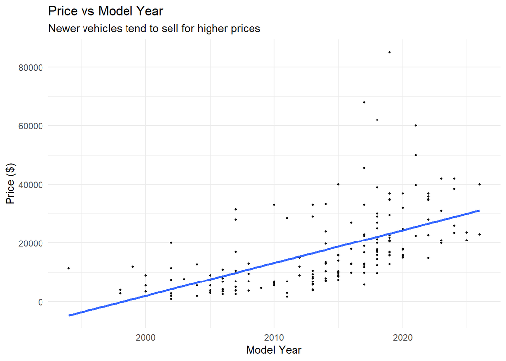

The scatterplot shows a positive relationship between model year and vehicle price. Newer vehicles generally sell for higher prices than older vehicles. This relationship supports including model year as an explanatory variable in the regression and machine learning models.

## Average Price by Make

Average vehicle prices vary substantially across manufacturers. Examining average prices by make helps identify differences between mainstream and luxury vehicle segments in the Bay Area used vehicle market.

| make | avg_price | listings |
| --- | --- | --- |
| Cadillac | 84995 | 80 |
| RAM | 41330 | 240 |
| Chevrolet | 37163.33333333334 | 480 |
| GMC | 33131.66666666666 | 240 |
| CHEVROLET | 31500 | 80 |
| Tesla | 29588.66666666667 | 240 |
| F | 29000 | 80 |
| 2007 | 28000 | 80 |
| Maserati | 27510 | 320 |
| Porsche | 26995 | 80 |

[output cut: 41 more lines]

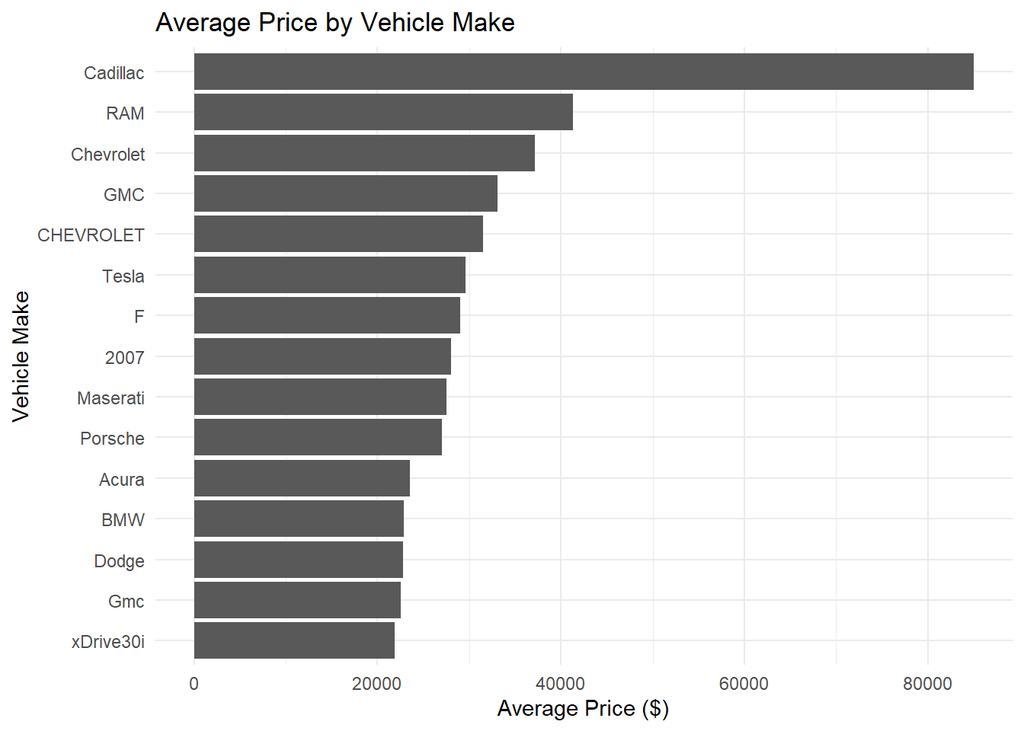

## Regression Analysis

Multiple regression is used to estimate the relationship between vehicle price and several explanatory variables simultaneously. The model evaluates how mileage, model year, and vehicle make influence market value while holding the other factors constant.

**Econometric Specification**

Pricê = β₀ + β₁(Mileage) + β₂(Year) + β₃(Make)

|  | Estimate | Std. Error | t value | Pr(>\|t\|) |
| --- | --- | --- | --- | --- |
| (Intercept) | -1585560.28 | 26612.298 | -59.58 | 0 |
| mileage | -0.086 | 0.002 | -44.676 | 0 |
| year | 799.724 | 13.199 | 60.591 | 0 |
| make1994 | 20654.017 | 1155.289 | 17.878 | 0 |
| make2007 | 19184.972 | 1150.812 | 16.671 | 0 |
| make2010 | 292.17 | 1150.437 | 0.254 | 0.8 |
| make2020 | -3195.123 | 1161.72 | -2.75 | 0.006 |
| makeAcura | 2430.718 | 955.999 | 2.543 | 0.011 |
| makeAudi | -6944.781 | 921.283 | -7.538 | 0 |
| makeBMW | 2328.256 | 864.528 | 2.693 | 0.007 |

[output cut: 43 more lines]

**Estimated Regression Equation**

Pricê = -1,586,000 − 0.086(Mileage) + 799.7(Year) + Make Effects

**Interpretation**

- Each additional mile reduces expected vehicle value by approximately $0.086.
- Each newer model year increases expected vehicle value by approximately $800.
- Vehicle make contributes to explaining differences in used vehicle market values.

While the regression model explains approximately 71% of the variation in vehicle prices, machine learning methods may capture additional nonlinear relationships and interactions between variables. The next section evaluates Random Forest models as an alternative predictive approach.

## Random Forest Analysis

Random Forest is an ensemble machine learning method that combines hundreds of decision trees to improve predictive accuracy. Unlike linear regression, Random Forest can capture nonlinear relationships and interactions among vehicle characteristics.

## 500

Trees

## 98.5%

Variance Explained

## 2,676,044

MSE

**Random Forest Results**

The Random Forest model explains approximately 98.5% of the variation in vehicle prices, compared with 71.3% for the multiple regression model. This substantial improvement indicates that nonlinear relationships and interactions among mileage, model year, and vehicle make are important determinants of vehicle value.

## #1

Mileage

## #2

Model Year

## #3

Vehicle Make

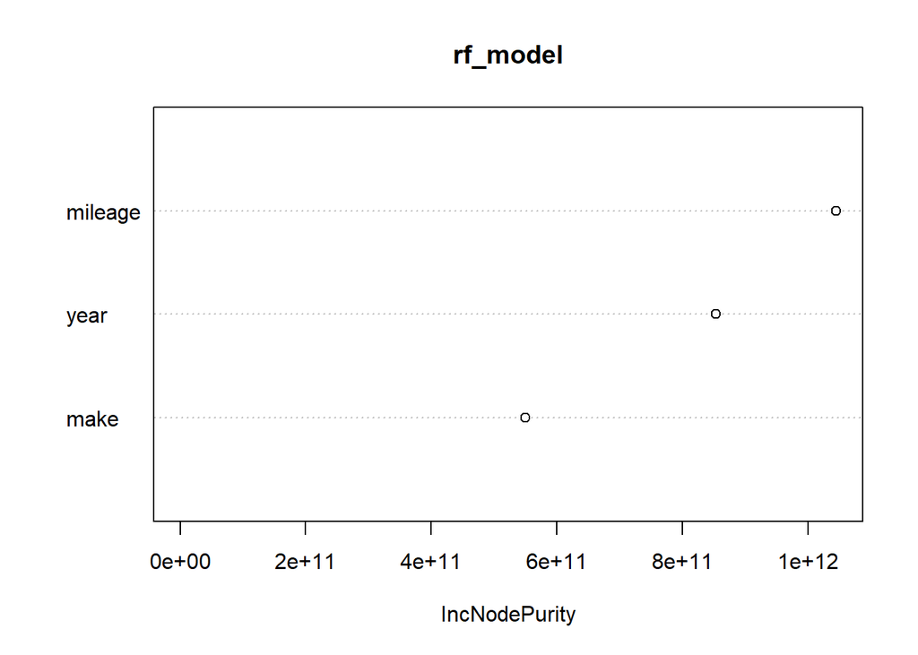

**Variable Importance Results**

The Random Forest variable importance plot shows that mileage is the strongest predictor of vehicle price, followed by model year and vehicle make. This result is consistent with the regression findings, where mileage had a negative relationship with price and model year had a positive relationship with price.

Although vehicle make is less important than mileage and year, it still adds predictive value by capturing brand-level differences in market pricing.

## XGBoost Model

XGBoost (Extreme Gradient Boosting) is a machine learning algorithm that builds trees sequentially, allowing each new tree to improve upon the errors of previous trees. XGBoost often achieves state-of-the-art predictive performance in structured data problems.

## XGBoost Analysis

```
## XGBoost model object
## Call:
##   xgboost(objective = "reg:squarederror", nrounds = 100, data = X,
##     label = y, verbose = 0)
## Objective: reg:squarederror
## Number of iterations: 100
## Number of features: 3
```

**XGBoost Results**

The XGBoost model was trained using mileage, model year, and vehicle make as predictors of vehicle price. XGBoost builds trees sequentially and often achieves superior predictive performance by capturing nonlinear relationships and interactions among variables.

## XGBoost Variable Importance

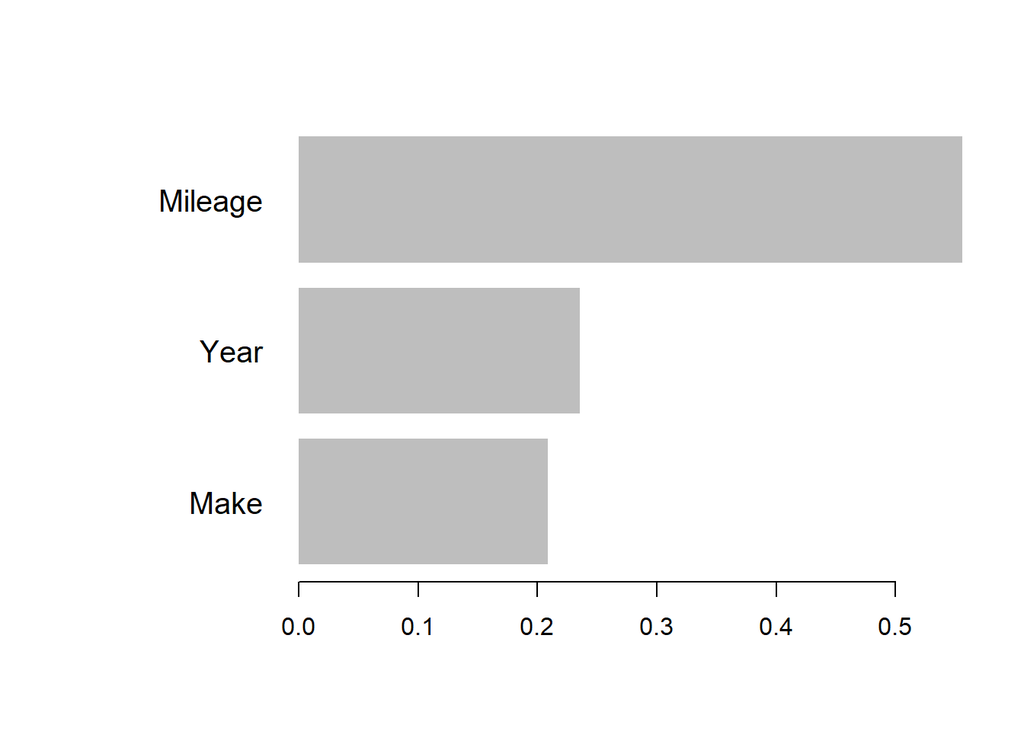

| Model | Performance |
| --- | --- |
| Multiple Regression | R squared = 0.713 |
| Random Forest | 98.5 percent variance explained |
| XGBoost | Advanced gradient boosting model |

**XGBoost Variable Importance Results**

The XGBoost model also identifies mileage as the strongest predictor of vehicle price, followed by model year and vehicle make. This is consistent with the Random Forest results and confirms that mileage and age are the most important factors in estimating used vehicle value.

## Vehicle Valuation Dashboard

**Market Price Comparison Tool**

This dashboard compares actual vehicle asking prices to model-predicted market values. The Difference column helps identify vehicles that may be priced above or below their estimated market value.

| title | make | year | mileage | price | Predicted_Price | Difference |
| --- | --- | --- | --- | --- | --- | --- |
| 2015 honda accord | honda | 2015 | 95000 | 14000 | 14205 | -205 |
| 2015 Honda Civic Coupe | Honda | 2015 | 113000 | 8900 | 11439 | -2539 |
| 2013 Land Rover Range Rover Sport | Land | 2013 | 129000 | 9400 | 11229 | -1829 |
| 2014 Maserati GranTurismo 2D Coupe (one owner/11k miles) | Maserati | 2014 | 12000 | 33250 | 27452 | 5798 |
| 2007 Lexus RX350 very well-kept, Clean title SMOG today, heated seats | Lexus | 2007 | 200000 | 3900 | 3569 | 331 |
| Toyota SIENNA 2004,2005,2006,2007,2008,2009,2010,2011,2012,le xle awd | SIENNA | 2004 | 111000 | 5555 | 5555 | 0 |
| 2018 RAM 3500 4x4 Crew Cab – 6.7L Cummins Turbo Diesel – Only 63K Mile | RAM | 2018 | 63000 | 62000 | 40937 | 21063 |
| 2009 TOYOTA COROLLA *NO OIL LEAK *SAVE GAS* BLUETOOTH | TOYOTA | 2009 | 207000 | 4650 | 2452 | 2198 |
| 2015 Mercedes S550 | Mercedes | 2015 | 85000 | 40000 | 21107 | 18893 |
| 2007 honda civic | honda | 2007 | 130000 | 5000 | 4795 | 205 |

[output cut: 14310 more lines]

### Custom Vehicle Prediction Example

| Make | Year | Mileage | Estimated_Price |
| --- | --- | --- | --- |
| Toyota | 2020 | 75000 | $24,727 |